# Day 2 class notes

Tabular data is the most common data type–most of the time, do some type of thing.

this situation, find what dat u need, use code, there are forms of data for no-tables,but those are for special things like network analysis, etc

u are responsible for finding the data type for your columns, every time we think about column, it is the same type–rows are different types. row is a record (observation).

you have to check what the data type is. In general, we can can

categorical data, quantitative data.

we will have a look at categorical data.

howeve, when we talk about text, when we find text, we usually dont do statistics on text, thats why u call in sometimes, key, colum where values do not repeat. You dont do statistics related tothhem, some columns like a text message can still be analyzed. u are not rly doing statisitcs, u are counting thigns. trying to recognize some particular sentiment in the langauge. good or bad. It is a work in progress, nonetheless.

```r
location='https://github.com/EvansDataScience/data/raw/master/'
file='eduwa.rda'
link=paste0(location,file) #The command paste0 is just combining pasting with both strings. those strings become the link


#getting the data TABLE from the file in the cloud:
load(file=url(link))
```

location is the location where the file is in github the filename is the name of the file in the location you dont need to do this, you can do everything in one line. if you are gonna work in seeral times in repo, you might want to save name of repo and just change name in one file. the less you change when u are coding, u lower the risk of mistyping. The command paste0 is just combining pasting with both strings. those strings become the link

in this case it is an rda file, which means i is a file created in r itself. whenever u have that kind of file, u can just use link. in general, r assngns, a file to an object. load command is not assingng to anything. the name eduwa is going to be the object

```r
names(eduwa)
```

```
 [1] "NCES.School.ID"        "State.School.ID"       "NCES.District.ID"
 [4] "State.District.ID"     "Low.Grade"             "High.Grade"
 [7] "School.Name"           "District"              "County"
[10] "Street.Address"        "City"                  "State"
[13] "ZIP"                   "ZIP.4-digit"           "Phone"
[16] "Locale.Code"           "LocaleType"            "LocaleSub"
[19] "Charter"               "Title.I.School"        "Title.1.School.Wide"
[22] "Student.Teacher.Ratio" "Free.Lunch"            "Reduced.Lunch"
```

pay atention, R can change the names to the variables/columns.

really, in excel, aren’t many restrictions to what you type in a spreadsheet, can be anything. if for some reason u open the file, r says–this is not a dataframe, or column names aren’t good, R may make some changes. a number at the beginning is not acceptable, it might change it. it acceps name1 but not 1name. ***

you cannot have rpated names you may have x and y and z

u have to be sure how R read your data, those are the filenames. in this situation, there are no spaces. whatever was a space was replaced by a dot, its one choice, could be _, could be a -,

now we gonna find data types

```r
# this 'width = 70,strict.width='cut' means
# you do not want to see more than 70 characters per row.

str(eduwa,width = 70,strict.width='cut')
```

```
'data.frame':   2427 obs. of  24 variables:
 $ NCES.School.ID       : chr  "530486002475" "530270001270" "53091"..
 $ State.School.ID      : chr  "WA-31025-1656" "WA-06114-1646" "WA-"..
 $ NCES.District.ID     : chr  "5304860" "5302700" "5309100" "53000"..
 $ State.District.ID    : chr  "WA-31025" "WA-06114" "WA-34033" "WA"..
 $ Low.Grade            : Ord.factor w/ 14 levels "PK"<"KG"<"1"<..: ..
 $ High.Grade           : Ord.factor w/ 15 levels "PK"<"KG"<"1"<..: ..
 $ School.Name          : chr  "10th Street School" "49th Street Ac"..
 $ District             : chr  "Marysville School District" "Evergr"..
 $ County               : chr  "Snohomish" "Clark" "Thurston" "Gray"..
 $ Street.Address       : chr  "7204 27th Ave NE" "14619B NE 49th S"..
 $ City                 : chr  "Marysville" "Vancouver" "Tumwater" "..
 $ State                : chr  "WA" "WA" "WA" "WA" ...
 $ ZIP                  : chr  "98271" "98682" "98512" "98520" ...
 $ ZIP.4-digit          : chr  NA "6308" NA "5510" ...
 $ Phone                : chr  "(360)965-0400" "(360)604-6700" "(36"..
 $ Locale.Code          : Factor w/ 12 levels "11","12","13",..: 5 2..
 $ LocaleType           : Factor w/ 4 levels "City","Rural",..: 3 1 ..
 $ LocaleSub            : Factor w/ 12 levels "City: Small",..: 5 2 ..
 $ Charter              : Factor w/ 2 levels "No","Yes": 1 1 1 1 1 1..
 $ Title.I.School       : Factor w/ 2 levels "No","Yes": 2 1 1 2 1 1..
 $ Title.1.School.Wide  : Factor w/ 2 levels "No","Yes": 2 NA NA 2 N..
 $ Student.Teacher.Ratio: num  23.4 8.4 21.5 15.9 6.5 15.3 NA 16.3 1..
 $ Free.Lunch           : num  28 53 169 292 12 411 48 102 101 268 ...
 $ Reduced.Lunch        : num  3 9 40 10 4 23 12 22 23 0 ...
```

he gave us a clean dataset, he made sure it was ordinal, in district, maybe r might have red it as an integer value, but he made sure it was a text. this file has been pre-processed.

u dunno how r is gonna understand it, use this command after upload, if you see a chr when i should be int, you should change it, you can ask prof if you dont kno how to change it.

1 column should just be 1 data type, if in excel, whenever u dont have a value, u write a dash or an x, when R reads in the data, everything will be considered as a character. you just leave it empty in general. if u use a differnt symbol, u might be in trouble.. thats not always the case, if u download data from UN, maybe they have different vals.

there are different libraries that read data from excel.

categorical data are the output of a classifiction process. the calssificaton can propose an incrememnetal or on-incremental differentiation. INCREMENTAL data are ordinal. non-incremental are nominal data

sometimes, the data is coded, 1-2-3 could be a nominal data, 1 means north, 2 means west, 3 means east….

if u are all doctors, for this variable we can use more complicated things. when u are presenting, u dont have time to know what a certain plot means.

Visualization for nominal tables

we have names of these, nominal and ordinal

```r
head(eduwa$LocaleType,20) #first twenty values
```

```
 [1] Suburb City   City   Town   City   City
 [7] Suburb City   Rural  Rural  City   City
[13] City   City   Suburb Rural  Rural  Rural
[19] Suburb City
Levels: City Rural Suburb Town
```

let’s do a simple frequency table:

We want to go very good, cimple plots

```r
# absolute values
absoluteT=table(eduwa$LocaleType,
                exclude = 'nothing') #include all values!
#here you are:
absoluteT
```

```
  City  Rural Suburb   Town   <NA>
   714    505    798    338     72
```

BY DEFAULT, R will excude issing values, so exclude = ‘nothing’ gets us the missing values.

missing vals.. political stakeholders dont kno much about math, but they kno how many cities king county has, they know how many counties WA has, when u present simple plot, they just start adding. they ask what happened to the others.

give a good name to the missing values. unknown. try to find a good name, so when they add everything up, they can determiine those missing things

dataframe$var

next time u are in categorical data, right thing to do is prepare frequency table

absolute count can be transformed into percent or relative frequencies

```r
# relative values
prop.table(absoluteT)
```

```
      City      Rural     Suburb       Town
0.29419036 0.20807581 0.32880099 0.13926658
      <NA>
0.02966625
```

we should try using all info possible–good iedea to name the missing values…

```r
names(absoluteT)[5]='Unknown'
```

if u want the range of proportons to be in percents, u should do:

```r
propT=prop.table(absoluteT)*100
#you get
propT
```

```
     City     Rural    Suburb      Town   Unknown
29.419036 20.807581 32.880099 13.926658  2.966625
```

pie plot gets criticism. our brain isn’t good at decoding exact sanlges, city/suburbs

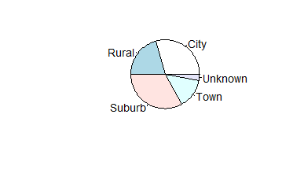

```r
#the pie plots the table:
pie(absoluteT)
```

try avoiding them except for 2 values, but if it’s close u might not see the difference.

```r
#load ggplot
library(ggplot2)
```

absolute T is not a dataframe, ggplot require us t ipnput a dataframe, otherise they wont understand, if u have the table of coutns/freqnency table, command, output of command table is not a data frame, is frequency table

First, turn the frequency table into a data frame

```r
# as data frame
(tableFreq=as.data.frame(absoluteT))
```

| Var1 | Freq |
| --- | --- |
| City | 714 |
| Rural | 505 |
| Suburb | 798 |
| Town | 338 |
| Unknown | 72 |

if u dont do anything, those are the dataframe column names, when u input that into ggplot, they will use those names. u have 2 options, you can change the names in GGplot later, or u can change it now in the data frame itself.

it is rly up 2 u,

```r
#renaming data frame columns.
names(tableFreq)=c("Locale","Count")
#adding percents
#add as.vector so ggplot doesn't complain later
tableFreq$Percent=as.vector(propT)
#then you have:
tableFreq
```

| Locale | Count | Percent |
| --- | --- | --- |
| City | 714 | 29.419036 |
| Rural | 505 | 20.807581 |
| Suburb | 798 | 32.880099 |
| Town | 338 | 13.926658 |
| Unknown | 72 | 2.966625 |

what is the idea of ggplot? ggplot tells u, i could give u all the power u want to customize the plot as much as u want. the good things is u can do it step by step. it is, as the name implies, you can mke a simple sentence, and you can increase the grammar, make tit mrore complex.

Create the BASE object, which is not a plot, just transforming the main variables

```r
#base GGPLOT2 starts with a "base", telling WHAT VARIABLES TO PLOT
base= ggplot(data = tableFreq,
             aes(x = Locale,
                 y = Count))
```

base is telling ggplot what data frame ur gonna use, and what values u gonna plot

once u have the base plot, you can slowly make the base plot more and more complex.

aesthetics is what your actually going to be using in the plot

x is the locale, y is the count

geombar inherits the aesthetics from the base, geombar knows because it is inherited int he information that is coming from the base.

stat = identity, means just use whatever u find.

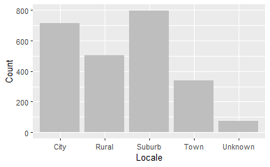

```r
plot1 = base + geom_bar(fill = "gray",
                        stat = 'identity')
plot1
```

u made a frequency table, and then u turned the frequency table into a dataframe, when u are here, u should be relieved. from there, everything else can be added.

you have the default bar plot now, from here, everything else can be added.

You have a default bar plot now. From here, you start adding more layers that will change the default.

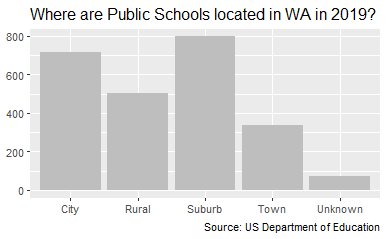

```r
#adding titles
titleText='Where are Public Schools located in WA in 2019?'
sourceText='Source: US Department of Education'

plot2 = plot1 + labs(title=titleText,
                     x =NULL,
                     y = NULL,
                     caption = sourceText)
plot2
```

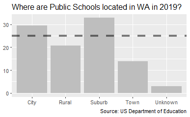

```r
base= ggplot(data = tableFreq,
             aes(x = Locale,
                 y = Percent))

plot1 = base + geom_bar(fill ="gray",
                        stat = 'identity')

plot2 = plot1 + labs(title=titleText,
                     x =NULL,
                     y = NULL,
                     caption = sourceText)

plot3 = plot2 + geom_hline(yintercept = 25, #where
                           linetype="dashed",
                           size=1.5, #thickness
                           alpha=0.5) #transparency
plot3
```

adding a reference line for what is above and below,

Customize the vertical axes

load scales

```r
library(scales) # for "unit_format""
```

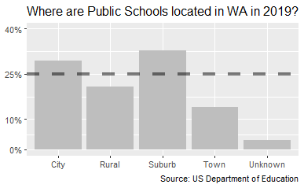

```r
#customize Y axis
plot4 = plot3 +
  scale_y_continuous(breaks=c(0,10, 25,40),
        limits = c(0, 40),
        labels=unit_format(suffix = '%'))
plot4
```

shows where the breaks are shows the upper and lower limits creates blabels for the unit format, a suffix that is a percent

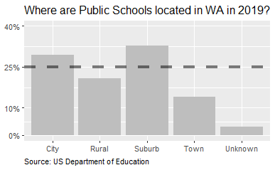

```r
#positions: 0 left / 1 right / 0.5 center
plot5 = plot4 +
  theme(plot.caption = element_text(hjust = 0),
      plot.title = element_text(hjust = 0.5))
plot5
```

the plot captaion, where to horizontally adjust where the source text is plot title, where to put the title of the thing

Now there is a thing called THEME

annotating the bars, would u like these values in these bars

```r
paste0(round(tableFreq$Percent,2), '%')
```

```
[1] "29.42%" "20.81%" "32.88%" "13.93%" "2.97%"
```

paste0 is combining two different things, roudnig the frequency table to 2 decimal points, and then adding percent.

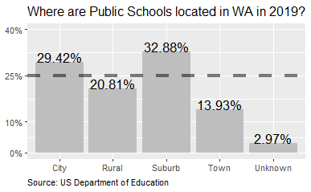

```r
# createing labels:
LABELS=paste0(round(tableFreq$Percent,2), '%')
###
plot6 = plot5 + geom_text(vjust=0, #hjust if flipping
                          size = 5,
                          aes(y = Percent ,
                              label = LABELS))
plot6#+ coord_flip() # wanna flip the plot?
```

dispersion is not applicable to nominal data

it can be good to order the bar plots by height.

```r
tableFreq=tableFreq[order(tableFreq$Percent),]
# then:
tableFreq
```

|  | Locale | Count | Percent |
| --- | --- | --- | --- |
| 5 | Unknown | 72 | 2.966625 |
| 4 | Town | 338 | 13.926658 |
| 2 | Rural | 505 | 20.807581 |
| 1 | City | 714 | 29.419036 |
| 3 | Suburb | 798 | 32.880099 |

let’s save the order of locale

```r
(localesOrd=tableFreq[order(tableFreq$Percent),'Locale'])
```

```
[1] Unknown Town    Rural   City    Suburb
Levels: City Rural Suburb Town Unknown
```

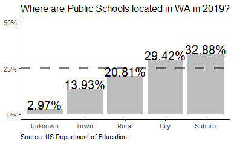

```r
# redo:
LABELS=paste0(round(tableFreq$Percent,2), '%')
base= ggplot(data = tableFreq,
             aes(x = Locale,y = Percent))
## adding these to base
base= base + scale_x_discrete(limits=localesOrd)
base= base + theme_classic()
##
plot1 = base + geom_bar(fill ="gray",
                        stat = 'identity')
plot2 = plot1 + labs(title=titleText,
                     x =NULL,
                     y = NULL,
                     caption = sourceText)
plot3 = plot2 + geom_hline(yintercept = 25,
                           linetype="dashed",
                           size=1.5,
                           alpha=0.5)
plot4 = plot3 + scale_y_continuous(breaks=c(0,25,50),
                                 limits = c(0, 50),
                                 # expand = c(0, 0), #try?
                            labels=unit_format(suffix = '%'))

plot5 = plot4 + theme(plot.caption = element_text(hjust = 0),
                      plot.title = element_text(hjust = 0.5))


plot6 = plot5 + geom_text(vjust=0, #hjust if flipping
                          size = 6,#fontface = "bold",
                          aes(y = Percent,
                              label = LABELS))
plot6 #+ coord_flip() # wanna flip the plot?
```

you can explore alternate visuals, use a geom_segment here rather than geom_bar.

differences is in the height,

Lolipop plot

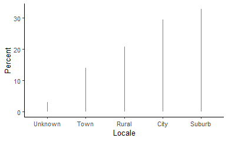

```r
#familiar
base = ggplot(tableFreq, aes(Locale,Percent))
#by default, with aes, first value is X, second value is y.
base = base + theme_classic()
base = base + scale_x_discrete(limits=localesOrd)
#new:geom_segment
lolliplot1=base + geom_segment(aes(y = 0,
                                   x = Locale,
                                   yend = Percent,
                                   xend = Locale),
                               color = "grey50")
lolliplot1
```

add the candy lol

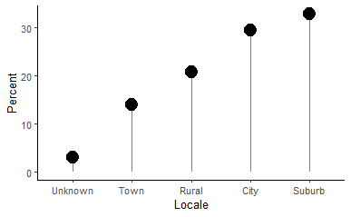

```r
lolliplot2=lolliplot1 + geom_point(size=5)
lolliplot2
```

```r
# new variable
tableFreq$gap=tableFreq$Percent-25
tableFreq
```

|  | Locale | Count | Percent | gap |
| --- | --- | --- | --- | --- |
| 5 | Unknown | 72 | 2.966625 | -22.033375 |
| 4 | Town | 338 | 13.926658 | -11.073342 |
| 2 | Rural | 505 | 20.807581 | -4.192419 |
| 1 | City | 714 | 29.419036 | 4.419036 |
| 3 | Suburb | 798 | 32.880099 | 7.880099 |

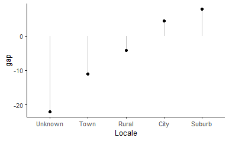

```r
base = ggplot(tableFreq, aes(x=Locale,
                             y=gap)) #change
base = base + theme_classic()
base = base + scale_x_discrete(limits=localesOrd)

lolliplot1=base + geom_segment(aes(y = 0,
                                   yend = gap, #change
                                   x = Locale,
                                   xend = Locale),
                               color = "gray")
lolliplot2 = lolliplot1 + geom_point()
lolliplot2
```

this is the gap between the percent and 25 percent. you can use that with the idea of it dropping or increasing.

add some color now

```r
# a new column for color
tableFreq$PositiveGap=ifelse(tableFreq$gap>0,"Yes","No")
tableFreq
```

|  | Locale | Count | Percent | gap | PositiveGap |
| --- | --- | --- | --- | --- | --- |
| 5 | Unknown | 72 | 2.966625 | -22.033375 | No |
| 4 | Town | 338 | 13.926658 | -11.073342 | No |
| 2 | Rural | 505 | 20.807581 | -4.192419 | No |
| 1 | City | 714 | 29.419036 | 4.419036 | Yes |
| 3 | Suburb | 798 | 32.880099 | 7.880099 | Yes |

adding color

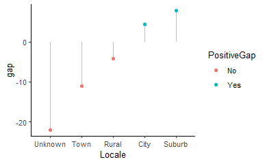

```r
# add new aesthetics 'color'
base = ggplot(tableFreq, aes(x=Locale,
                             y=gap,
                             color=PositiveGap))#here
base = base + theme_classic()
base= base + scale_x_discrete(limits=localesOrd)

lolliplot1=base + geom_segment(aes(y = 0,
                                   yend = gap,
                                   x = Locale,
                                   xend = Locale),
                               color = "gray")

lolliplot2 = lolliplot1 + geom_point()

lolliplot2
```

ggplot will use as many colors are there are levels there

maybe add a label in aes

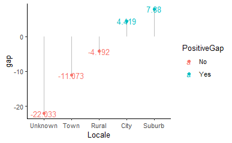

```r
base = ggplot(tableFreq, aes(x=Locale,y=gap,
                             color=PositiveGap,
                             label = round(gap,3))) #label

base = base + theme_classic()
base= base + scale_x_discrete(limits=localesOrd)

lolliplot1=base + geom_segment(aes(y = 0, yend = gap,
                                   x = Locale, xend = Locale),
                               color = "gray")

lolliplot2=lolliplot1 + geom_point()

lolliplot2 + geom_text()
```

we can nudge the text to the right

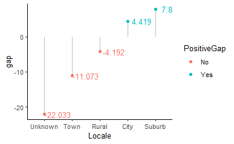

```r
lolliplot3= lolliplot2 + geom_text(nudge_x=0.5,#to the right
                                   show.legend = FALSE)
lolliplot3
```

positive gap or negative gap here.

adding the reference line

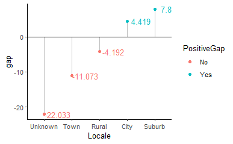

```r
lolliplot4 = lolliplot3 + geom_hline(yintercept = 0)
lolliplot4
```

but we can now get rid of shit lol

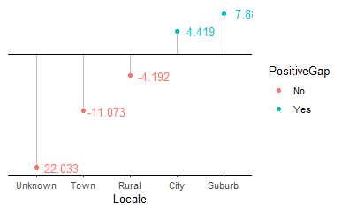

```r
# calling "element_blank()"
lolliplot5 = lolliplot4 + theme(axis.ticks.y = element_blank(),
                                axis.title.y = element_blank(),
                                axis.line.y = element_blank(),
                                axis.text.y = element_blank())
lolliplot5
```

Less elements:

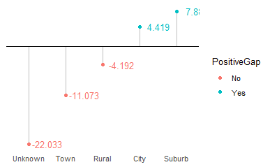

```r
# more "element_blank()"

lolliplot6=lolliplot5 + theme(axis.ticks.x = element_blank(),
                                axis.title.x = element_blank(),
                                axis.line.x = element_blank()
                              )
lolliplot6
```

move the legend INTO the graph

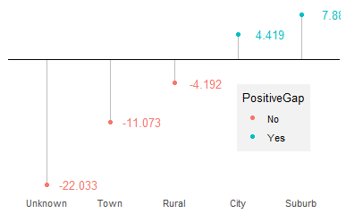

```r
lolliplot7= lolliplot6 + theme(legend.position = c(0.8,0.4),
                               legend.background = element_rect(fill='grey95'))
lolliplot7
```

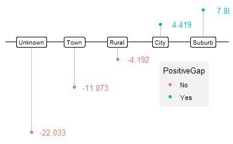

```r
lolliplot8 = lolliplot7 +  geom_label(aes(label=localesOrd),
                                      color ='black ',
                                      size =3,
                                      y=0,
                                      show.legend = FALSE ) +
             theme(axis.text.x = element_blank())
lolliplot8
```

##visualization for ordinal variables

use var that tells us highest grade offered in a school

```r
table(eduwa$High.Grade,exclude = 'nothing')
```

```
 PK  KG   1   2   3   4   5   6   7   8   9  10
 82   7   6  16  19  45 755 266  11 427  15   7
 11  12  13
  5 757   9
```

frequency tbale as adat frame

```r
frqTabO=as.data.frame(prop.table(table(eduwa$High.Grade)))
names(frqTabO)=c('grade','pct')
frqTabO
```

| grade | pct |
| --- | --- |
| PK | 0.033786568 |
| KG | 0.002884219 |
| 1 | 0.002472188 |
| 2 | 0.006592501 |
| 3 | 0.007828595 |
| 4 | 0.018541409 |
| 5 | 0.311083642 |
| 6 | 0.109600330 |
| 7 | 0.004532344 |
| 8 | 0.175937371 |

[output cut: 5 more lines]

u can use ggplot now

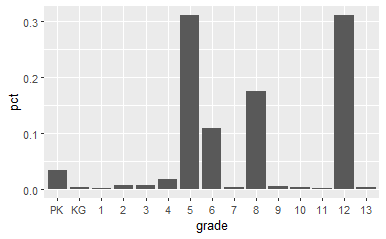

```r
base = ggplot(frqTabO,aes(x=grade,y=pct))
base + geom_bar(stat = 'identity')
```

but x ars have ORDER, increasing level in the values

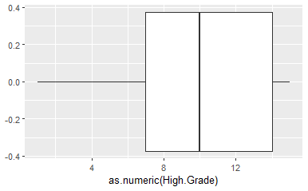

```r
# boxplots do not use frequency tables

# "as.numeric" produces turns levels of the factor into numbers
basebox1 = ggplot(eduwa, aes(y=as.numeric(High.Grade)))
box1 = basebox1 + geom_boxplot() + coord_flip() # to show it horizontally

box1
```

u dont use box plot to perceive counts, yu use it to perceive symmetry, distribution

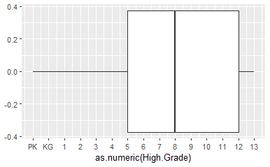

```r
# the labels use the original ordinal levels
ordLabels= levels(eduwa$High.Grade)

box2 = box1 + scale_y_continuous(labels=ordLabels,breaks=1:15)
box2
```

boxplot good for a technical report, but not for mass audience

PROJECT, maybe u dont have a categorical varable, nominal or ordinatl.

if u dont have it no problem, I can show u an example, how any ppl are getting free lunch in each school, it’s a number, but make categorial values fro umbers, in INTERVALS.

you cn create categorical variables from cuts.

```r
summary(eduwa$Free.Lunch)
```

```
   Min. 1st Qu.  Median    Mean 3rd Qu.    Max.
    0.0    52.0   140.0   179.4   245.2  1766.0
   NA's
    131
```

```r
eduwa$Free.LunchGroup=cut(eduwa$Free.Lunch,
                          breaks = c(0,100, 250, 500,1000,2000),
                          labels = c("100 and below","101-250","251-500","501-1000","1001 and above"))
```

new variable has this table:

```r
table(eduwa$Free.LunchGroup)
```

```
 100 and below        101-250        251-500
           790            840            448
      501-1000 1001 and above
           101             11
```

BEfore ext class, you work you contact him if you have any issues. at least, cut as told u if u do the basic one.

once you have every plot ready, the dashboard is not rocket science, it is just waiting for the plot.

get the college variable, see what u can do.